# Lesson 05

Christopher A. Swenson (chris@cswenson.com)

11/27/2021

## IQ and physical characteristics

Load the iqsize data. Display a scatterplot matrix of the data. Fit a multiple linear regression model of PIQ on Brain, Height, and Weight. Display model results. Use the anova function to display anova table with sequential (type I) sums of squares. Use the Anova function from the car package to display anova table with adjusted (type III) sums of squares.

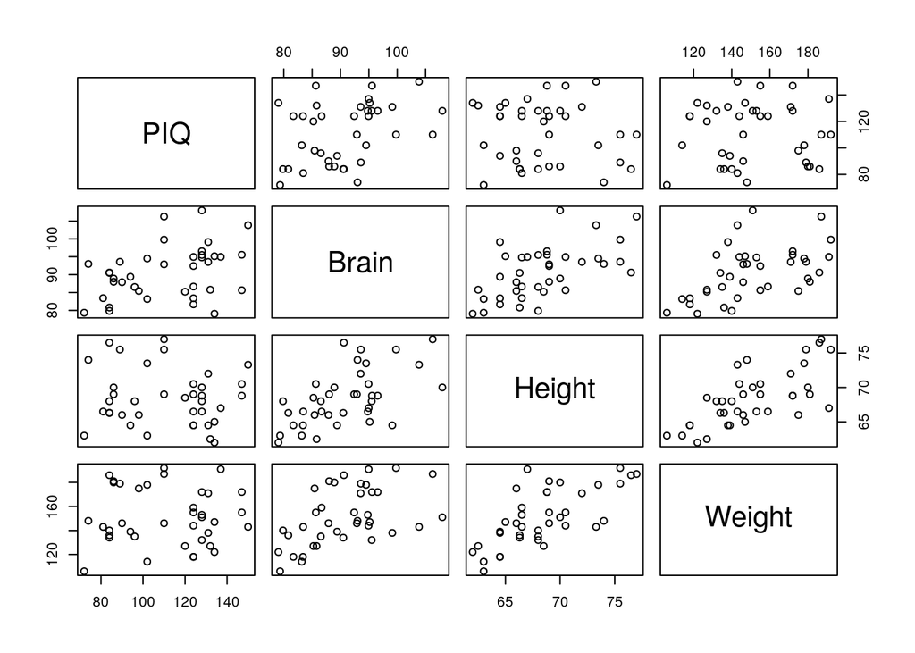

```r
iqsize <- read.table("./Data/iqsize.txt", header=T)
attach(iqsize)

pairs(cbind(PIQ, Brain, Height, Weight))
```

```r
model <- lm(PIQ ~ Brain + Height + Weight)
summary(model)
```

```
##
## Call:
## lm(formula = PIQ ~ Brain + Height + Weight)
##
## Residuals:
##    Min     1Q Median     3Q    Max
## -32.74 -12.09  -3.84  14.17  51.69
##
## Coefficients:
##               Estimate Std. Error t value Pr(>|t|)
## (Intercept)  1.114e+02  6.297e+01   1.768 0.085979 .
## Brain        2.060e+00  5.634e-01   3.657 0.000856 ***
## Height      -2.732e+00  1.229e+00  -2.222 0.033034 *
## Weight       5.599e-04  1.971e-01   0.003 0.997750
## ---
## Signif. codes:  0 '***' 0.001 '**' 0.01 '*' 0.05 '.' 0.1 ' ' 1
##
## Residual standard error: 19.79 on 34 degrees of freedom
## Multiple R-squared:  0.2949, Adjusted R-squared:  0.2327
## F-statistic: 4.741 on 3 and 34 DF,  p-value: 0.007215
```

```r
# Coefficients:
#               Estimate Std. Error t value Pr(>|t|)
# (Intercept)  1.114e+02  6.297e+01   1.768 0.085979 .
# Brain        2.060e+00  5.634e-01   3.657 0.000856 ***
# Height      -2.732e+00  1.229e+00  -2.222 0.033034 *
# Weight       5.599e-04  1.971e-01   0.003 0.997750
# ---
# Signif. codes:  0 ‘***’ 0.001 ‘**’ 0.01 ‘*’ 0.05 ‘.’ 0.1 ‘ ’ 1
#
# Residual standard error: 19.79 on 34 degrees of freedom
# Multiple R-squared:  0.2949,  Adjusted R-squared:  0.2327
# F-statistic: 4.741 on 3 and 34 DF,  p-value: 0.007215

anova(model) # Sequential (type I) SS
```

```
## Analysis of Variance Table
##
## Response: PIQ
##           Df  Sum Sq Mean Sq F value  Pr(>F)
## Brain      1  2697.1 2697.09  6.8835 0.01293 *
## Height     1  2875.6 2875.65  7.3392 0.01049 *
## Weight     1     0.0    0.00  0.0000 0.99775
## Residuals 34 13321.8  391.82
## ---
## Signif. codes:  0 '***' 0.001 '**' 0.01 '*' 0.05 '.' 0.1 ' ' 1
```

```r
# Analysis of Variance Table
# Response: PIQ
#           Df  Sum Sq Mean Sq F value  Pr(>F)
# Brain      1  2697.1 2697.09  6.8835 0.01293 *
# Height     1  2875.6 2875.65  7.3392 0.01049 *
# Weight     1     0.0    0.00  0.0000 0.99775
# Residuals 34 13321.8  391.82
# ---
# Signif. codes:  0 ‘***’ 0.001 ‘**’ 0.01 ‘*’ 0.05 ‘.’ 0.1 ‘ ’ 1

library(car)
Anova(model, type="III") # Adjusted (type III) SS
```

```
## Anova Table (Type III tests)
##
## Response: PIQ
##              Sum Sq Df F value    Pr(>F)
## (Intercept)  1225.2  1  3.1270 0.0859785 .
## Brain        5239.2  1 13.3716 0.0008556 ***
## Height       1934.7  1  4.9378 0.0330338 *
## Weight          0.0  1  0.0000 0.9977495
## Residuals   13321.8 34
## ---
## Signif. codes:  0 '***' 0.001 '**' 0.01 '*' 0.05 '.' 0.1 ' ' 1
```

```r
# Anova Table (Type III tests)
# Response: PIQ
#              Sum Sq Df F value    Pr(>F)
# (Intercept)  1225.2  1  3.1270 0.0859785 .
# Brain        5239.2  1 13.3716 0.0008556 ***
# Height       1934.7  1  4.9378 0.0330338 *
# Weight          0.0  1  0.0000 0.9977495
# Residuals   13321.8 34
# ---
# Signif. codes:  0 ‘***’ 0.001 ‘**’ 0.01 ‘*’ 0.05 ‘.’ 0.1 ‘ ’ 1

detach(iqsize)
```

## Underground air quality

Load the babybirds data. Display a scatterplot matrix of the data. Use the scatter3d function from the car package to create a 3D scatterplot of the data. Fit a multiple linear regression model of Vent on O2 and CO2. Display model results. Use the Anova function from the car package to display anova table with adjusted (type III) sums of squares.

```r
babybirds <- read.table("./Data/babybirds.txt", header=T)
attach(babybirds)
```

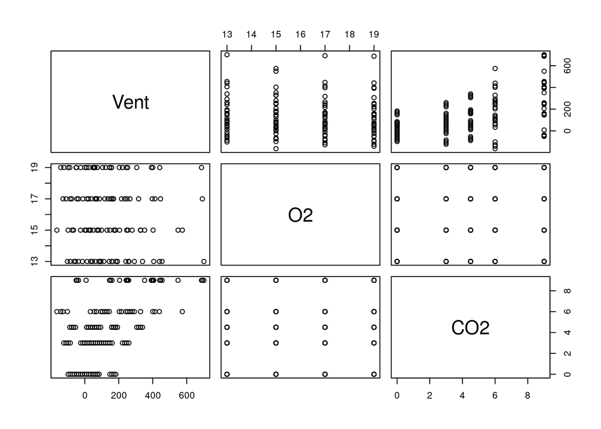

```r
pairs(cbind(Vent, O2, CO2))

library(car)
library(rgl) # need rgl library as well, install first
scatter3d(Vent ~ O2 + CO2)
```

[output not shown]

```r
#scatter3d(Vent ~ O2 + CO2, revolutions=3, speed=0.5, grid=F)

model <- lm(Vent ~ O2 + CO2)
summary(model)
```

```
##
## Call:
## lm(formula = Vent ~ O2 + CO2)
##
## Residuals:
##     Min      1Q  Median      3Q     Max
## -356.57  -96.50    8.73   84.68  422.44
##
## Coefficients:
##             Estimate Std. Error t value Pr(>|t|)
## (Intercept)   85.901    106.006   0.810    0.419
## O2            -5.330      6.425  -0.830    0.408
## CO2           31.103      4.789   6.495  2.1e-09 ***
## ---
## Signif. codes:  0 '***' 0.001 '**' 0.01 '*' 0.05 '.' 0.1 ' ' 1
##
## Residual standard error: 157.4 on 117 degrees of freedom
## Multiple R-squared:  0.2682, Adjusted R-squared:  0.2557
## F-statistic: 21.44 on 2 and 117 DF,  p-value: 1.169e-08
```

```r
# Coefficients:
#             Estimate Std. Error t value Pr(>|t|)
# (Intercept)   85.901    106.006   0.810    0.419
# O2            -5.330      6.425  -0.830    0.408
# CO2           31.103      4.789   6.495  2.1e-09 ***
# ---
# Signif. codes:  0 ‘***’ 0.001 ‘**’ 0.01 ‘*’ 0.05 ‘.’ 0.1 ‘ ’ 1
#
# Residual standard error: 157.4 on 117 degrees of freedom
# Multiple R-squared:  0.2682,  Adjusted R-squared:  0.2557
# F-statistic: 21.44 on 2 and 117 DF,  p-value: 1.169e-08

Anova(model, type="III") # Adjusted (type III) SS
```

```
## Anova Table (Type III tests)
##
## Response: Vent
##              Sum Sq  Df F value    Pr(>F)
## (Intercept)   16262   1  0.6566    0.4194
## O2            17045   1  0.6883    0.4084
## CO2         1044773   1 42.1866 2.104e-09 ***
## Residuals   2897566 117
## ---
## Signif. codes:  0 '***' 0.001 '**' 0.01 '*' 0.05 '.' 0.1 ' ' 1
```

```r
# Anova Table (Type III tests)
# Response: Vent
#              Sum Sq  Df F value    Pr(>F)
# (Intercept)   16262   1  0.6566    0.4194
# O2            17045   1  0.6883    0.4084
# CO2         1044773   1 42.1866 2.104e-09 ***
# Residuals   2897566 117
# ---
# Signif. codes:  0 ‘***’ 0.001 ‘**’ 0.01 ‘*’ 0.05 ‘.’ 0.1 ‘ ’ 1

detach(babybirds)
```

## Soapsuds example (using matrices)

```r
soapsuds <- read.table("./Data/soapsuds.txt", header=T)
attach(soapsuds)

model <- lm(suds ~ soap, x=T)
summary(model)
```

```
##
## Call:
## lm(formula = suds ~ soap, x = T)
##
## Residuals:
##       1       2       3       4       5       6       7
## -2.3214  1.9286  0.1786  1.4286 -1.3214  1.9286 -1.8214
##
## Coefficients:
##             Estimate Std. Error t value Pr(>|t|)
## (Intercept)  -2.6786     4.2220  -0.634    0.554
## soap          9.5000     0.7553  12.579 5.64e-05 ***
## ---
## Signif. codes:  0 '***' 0.001 '**' 0.01 '*' 0.05 '.' 0.1 ' ' 1
##
## Residual standard error: 1.998 on 5 degrees of freedom
## Multiple R-squared:  0.9694, Adjusted R-squared:  0.9632
## F-statistic: 158.2 on 1 and 5 DF,  p-value: 5.639e-05
```

```r
# Coefficients:
#             Estimate Std. Error t value Pr(>|t|)
# (Intercept)  -2.6786     4.2220  -0.634    0.554
# soap          9.5000     0.7553  12.579 5.64e-05 ***

X <- model$x
t(X) %*% X
```

```
##             (Intercept)   soap
## (Intercept)         7.0  38.50
## soap               38.5 218.75
```

```r
#             (Intercept)   soap
# (Intercept)         7.0  38.50
# soap               38.5 218.75

t(X) %*% suds
```

```
##             [,1]
## (Intercept)  347
## soap        1975
```

```r
#             [,1]
# (Intercept)  347
# soap        1975

solve(t(X) %*% X)
```

```
##             (Intercept)       soap
## (Intercept)   4.4642857 -0.7857143
## soap         -0.7857143  0.1428571
```

```r
#             (Intercept)       soap
# (Intercept)   4.4642857 -0.7857143
# soap         -0.7857143  0.1428571

solve(t(X) %*% X) %*% (t(X) %*% suds)
```

```
##                  [,1]
## (Intercept) -2.678571
## soap         9.500000
```

```r
#                  [,1]
# (Intercept) -2.678571
# soap         9.500000

soap2 <- 2*soap
model <- lm(suds ~ soap + soap2)
summary(model)
```

```
##
## Call:
## lm(formula = suds ~ soap + soap2)
##
## Residuals:
##       1       2       3       4       5       6       7
## -2.3214  1.9286  0.1786  1.4286 -1.3214  1.9286 -1.8214
##
## Coefficients: (1 not defined because of singularities)
##             Estimate Std. Error t value Pr(>|t|)
## (Intercept)  -2.6786     4.2220  -0.634    0.554
## soap          9.5000     0.7553  12.579 5.64e-05 ***
## soap2             NA         NA      NA       NA
## ---
## Signif. codes:  0 '***' 0.001 '**' 0.01 '*' 0.05 '.' 0.1 ' ' 1
##
## Residual standard error: 1.998 on 5 degrees of freedom
## Multiple R-squared:  0.9694, Adjusted R-squared:  0.9632
## F-statistic: 158.2 on 1 and 5 DF,  p-value: 5.639e-05
```

```r
# Coefficients: (1 not defined because of singularities)
#             Estimate Std. Error t value Pr(>|t|)
# (Intercept)  -2.6786     4.2220  -0.634    0.554
# soap          9.5000     0.7553  12.579 5.64e-05 ***
# soap2             NA         NA      NA       NA

detach(soapsuds)
```

## Pastry sweetness

Load the pastry data. Calculate the correlation between the predictors and create a scatterplot. Fit a multiple linear regression model of Rating on Moisture and Sweetness and display the model results. Create a scatterplot of the data with points marked by Sweetness and two lines representing the fitted regression equation for each sweetness level. Fit a simple linear regression model of Rating on Moisture and display the model results. Fit a simple linear regression model of Rating on Sweetness and display the model results.

```r
pastry <- read.table("./Data/pastry.txt", header=T)
attach(pastry)

cor(Sweetness, Moisture) # 0
```

```
## [1] 0
```

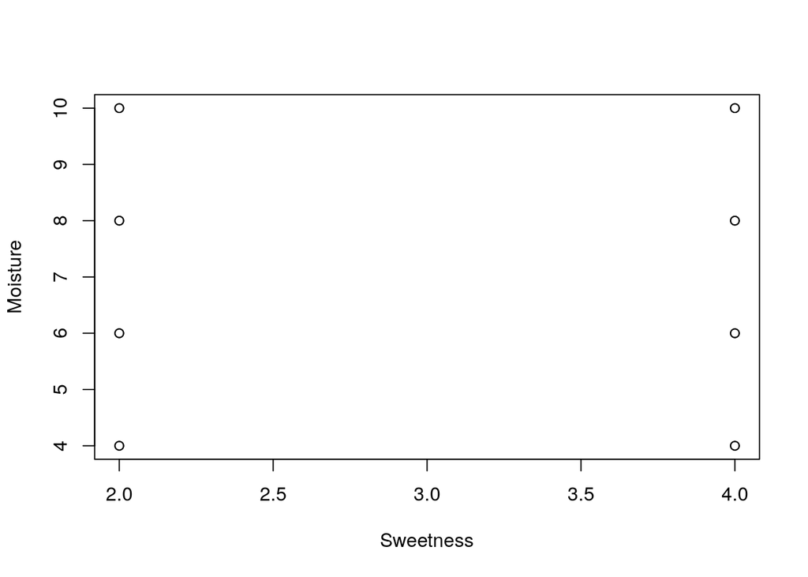

```r
plot(Sweetness, Moisture)
```

```r
model.12 <- lm(Rating ~ Moisture + Sweetness)
summary(model.12)
```

```
##
## Call:
## lm(formula = Rating ~ Moisture + Sweetness)
##
## Residuals:
##    Min     1Q Median     3Q    Max
## -4.400 -1.762  0.025  1.587  4.200
##
## Coefficients:
##             Estimate Std. Error t value Pr(>|t|)
## (Intercept)  37.6500     2.9961  12.566 1.20e-08 ***
## Moisture      4.4250     0.3011  14.695 1.78e-09 ***
## Sweetness     4.3750     0.6733   6.498 2.01e-05 ***
## ---
## Signif. codes:  0 '***' 0.001 '**' 0.01 '*' 0.05 '.' 0.1 ' ' 1
##
## Residual standard error: 2.693 on 13 degrees of freedom
## Multiple R-squared:  0.9521, Adjusted R-squared:  0.9447
## F-statistic: 129.1 on 2 and 13 DF,  p-value: 2.658e-09
```

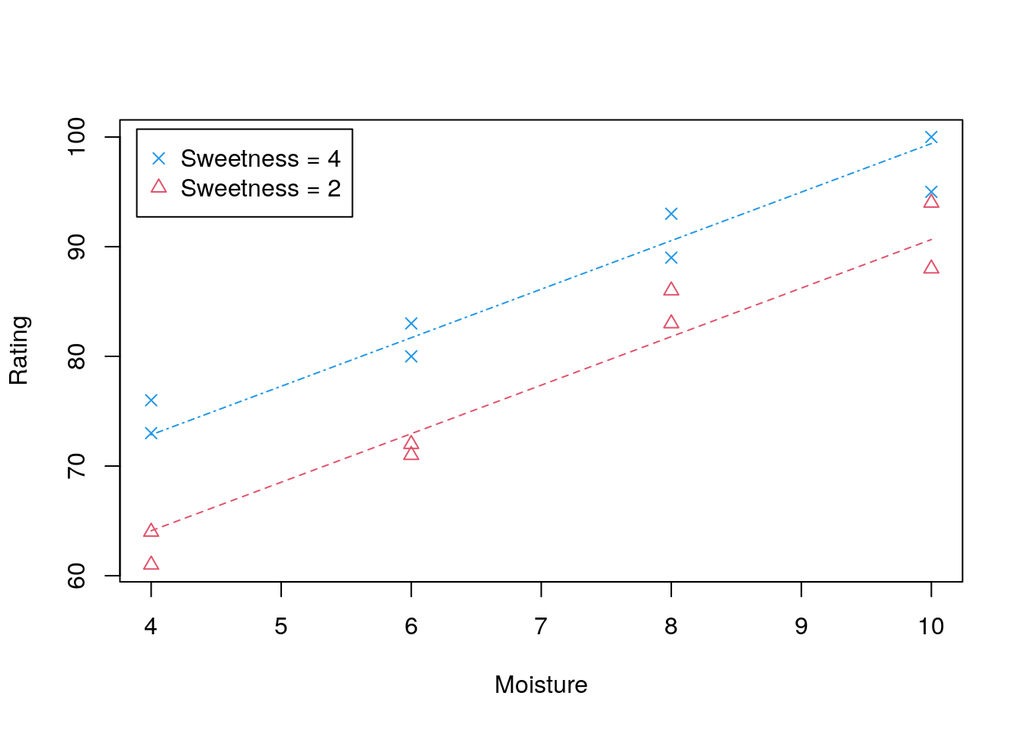

```r
#             Estimate Std. Error t value Pr(>|t|)
# (Intercept)  37.6500     2.9961  12.566 1.20e-08 ***
# Moisture      4.4250     0.3011  14.695 1.78e-09 ***
# Sweetness     4.3750     0.6733   6.498 2.01e-05 ***
# ---
# Signif. codes:  0 ‘***’ 0.001 ‘**’ 0.01 ‘*’ 0.05 ‘.’ 0.1 ‘ ’ 1
#
# Residual standard error: 2.693 on 13 degrees of freedom
# Multiple R-squared:  0.9521,  Adjusted R-squared:  0.9447
# F-statistic: 129.1 on 2 and 13 DF,  p-value: 2.658e-09

plot(Moisture, Rating, type="n")
for (i in 1:16) points(Moisture[i], Rating[i], pch=Sweetness[i], col=Sweetness[i])
for (i in c(2,4)) lines(Moisture[Sweetness==i], fitted(model.12)[Sweetness==i],
                        lty=i, col=i)
legend("topleft", legend=c("Sweetness = 4",
                           "Sweetness = 2"),
       col=c(4,2), pch=c(4,2), inset=0.02)
```

```r
model.1 <- lm(Rating ~ Moisture)
summary(model.1)
```

```
##
## Call:
## lm(formula = Rating ~ Moisture)
##
## Residuals:
##    Min     1Q Median     3Q    Max
## -7.475 -4.688 -0.100  4.638  7.525
##
## Coefficients:
##             Estimate Std. Error t value Pr(>|t|)
## (Intercept)   50.775      4.395  11.554 1.52e-08 ***
## Moisture       4.425      0.598   7.399 3.36e-06 ***
## ---
## Signif. codes:  0 '***' 0.001 '**' 0.01 '*' 0.05 '.' 0.1 ' ' 1
##
## Residual standard error: 5.349 on 14 degrees of freedom
## Multiple R-squared:  0.7964, Adjusted R-squared:  0.7818
## F-statistic: 54.75 on 1 and 14 DF,  p-value: 3.356e-06
```

```r
#             Estimate Std. Error t value Pr(>|t|)
# (Intercept)   50.775      4.395  11.554 1.52e-08 ***
# Moisture       4.425      0.598   7.399 3.36e-06 ***
# ---
# Signif. codes:  0 ‘***’ 0.001 ‘**’ 0.01 ‘*’ 0.05 ‘.’ 0.1 ‘ ’ 1
#
# Residual standard error: 5.349 on 14 degrees of freedom
# Multiple R-squared:  0.7964,  Adjusted R-squared:  0.7818
# F-statistic: 54.75 on 1 and 14 DF,  p-value: 3.356e-06

model.2 <- lm(Rating ~ Sweetness)
summary(model.2)
```

```
##
## Call:
## lm(formula = Rating ~ Sweetness)
##
## Residuals:
##     Min      1Q  Median      3Q     Max
## -16.375  -7.312  -0.125   8.688  16.625
##
## Coefficients:
##             Estimate Std. Error t value Pr(>|t|)
## (Intercept)   68.625      8.610   7.970 1.43e-06 ***
## Sweetness      4.375      2.723   1.607     0.13
## ---
## Signif. codes:  0 '***' 0.001 '**' 0.01 '*' 0.05 '.' 0.1 ' ' 1
##
## Residual standard error: 10.89 on 14 degrees of freedom
## Multiple R-squared:  0.1557, Adjusted R-squared:  0.09539
## F-statistic: 2.582 on 1 and 14 DF,  p-value: 0.1304
```

```r
#             Estimate Std. Error t value Pr(>|t|)
# (Intercept)   68.625      8.610   7.970 1.43e-06 ***
# Sweetness      4.375      2.723   1.607     0.13
# ---
# Signif. codes:  0 ‘***’ 0.001 ‘**’ 0.01 ‘*’ 0.05 ‘.’ 0.1 ‘ ’ 1
#
# Residual standard error: 10.89 on 14 degrees of freedom
# Multiple R-squared:  0.1557,  Adjusted R-squared:  0.09539
# F-statistic: 2.582 on 1 and 14 DF,  p-value: 0.1304

detach(pastry)
```

## Female stat students

Load the statfemales data. Display a scatterplot matrix of the data. Fit a multiple linear regression model of Height on momheight and dadheight and display the model results. Create a residual plot.

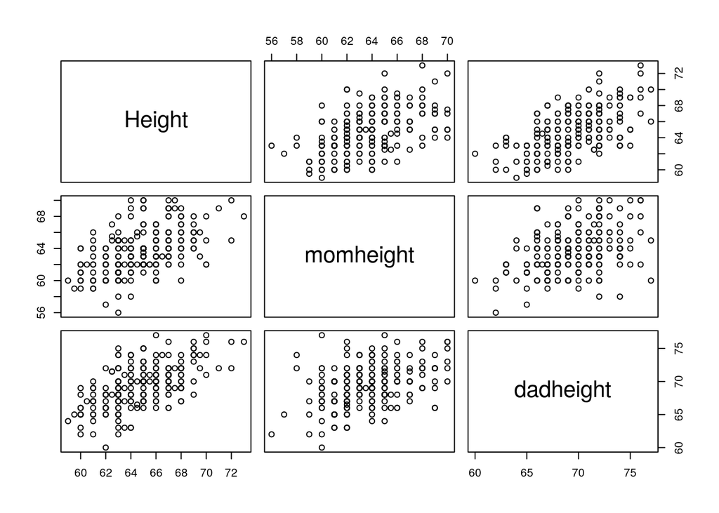

```r
statfemales <- read.table("./Data/stat_females.txt", header=T)
attach(statfemales)

pairs(cbind(Height, momheight, dadheight))
```

```r
model <- lm(Height ~ momheight + dadheight)
summary(model)
```

```
##
## Call:
## lm(formula = Height ~ momheight + dadheight)
##
## Residuals:
##     Min      1Q  Median      3Q     Max
## -5.2748 -1.5562 -0.0372  1.4721  5.7993
##
## Coefficients:
##             Estimate Std. Error t value Pr(>|t|)
## (Intercept) 18.54725    3.69278   5.023 1.08e-06 ***
## momheight    0.30351    0.05446   5.573 7.61e-08 ***
## dadheight    0.38786    0.04721   8.216 2.10e-14 ***
## ---
## Signif. codes:  0 '***' 0.001 '**' 0.01 '*' 0.05 '.' 0.1 ' ' 1
##
## Residual standard error: 2.031 on 211 degrees of freedom
## Multiple R-squared:  0.4335, Adjusted R-squared:  0.4281
## F-statistic: 80.73 on 2 and 211 DF,  p-value: < 2.2e-16
```

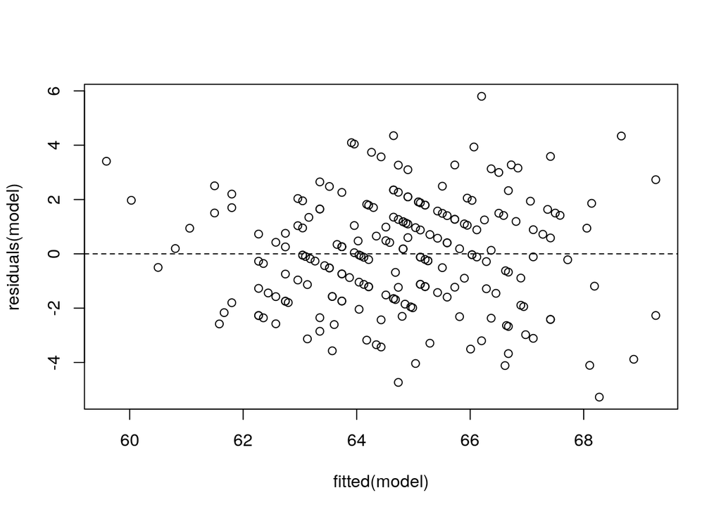

```r
#             Estimate Std. Error t value Pr(>|t|)
# (Intercept) 18.54725    3.69278   5.023 1.08e-06 ***
# momheight    0.30351    0.05446   5.573 7.61e-08 ***
# dadheight    0.38786    0.04721   8.216 2.10e-14 ***
# ---
# Signif. codes:  0 ‘***’ 0.001 ‘**’ 0.01 ‘*’ 0.05 ‘.’ 0.1 ‘ ’ 1
#
# Residual standard error: 2.031 on 211 degrees of freedom
# Multiple R-squared:  0.4335,  Adjusted R-squared:  0.4281
# F-statistic: 80.73 on 2 and 211 DF,  p-value: < 2.2e-16

plot(fitted(model), residuals(model),
     panel.last = abline(h=0, lty=2))
```

```r
detach(statfemales)
```